# Лабораторная работа №3

Дисциплина: Основы информационной безопасности.

Лобанова П. И.

Российский университет дружбы народов, Москва, Россия

15 марта 2024

# Информация

## Докладчик

- Лобанова Полина Иннокентьевна
- Учащаяся на направлении “Компьютерные и информационные технологии”
- Студентка группы НКАбд-01-22
- polla-2004@mail.ru

# Цель

Получение практических навыков работы в консоли с атрибутами файлов для групп пользователей.

# Выполнение лабораторной работы

1. В установленной операционной системе создадим учётную запись пользователя guest. Поскольку мы уже делали это в прошлой лабораторной работе, такой пользователь у меня уже есть.

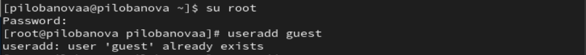

*Создание пользователя guest.*

2. Аналогично создадим второго пользователя guest2.

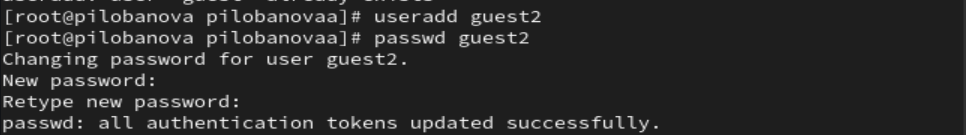

*Создание пользователя guest2.*

## .

3. Добавим пользователя guest2 в группу guest.

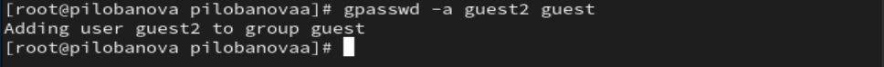

*Добавление пользователя guest2 в группу guest.*

## .

4. Осуществим вход в систему от двух пользователей на двух разных консолях.

[figure not shown]

*Консоли с двумя разными пользователями.*

## .

5. Для обоих пользователей командой pwd определим директорию, в которой находимся.

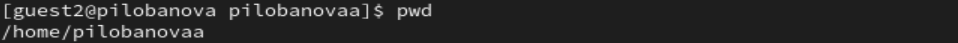

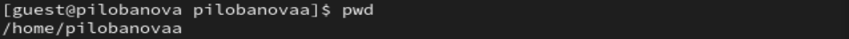

## .

6. Уточним имя пользователя, его группу, кто входит в неё и к каким группам принадлежит он сам. Определим командами groups guest и groups guest2, в какие группы входят пользователи guest и guest2. Сравним вывод команды groups с выводом команд id -Gn и id -G.

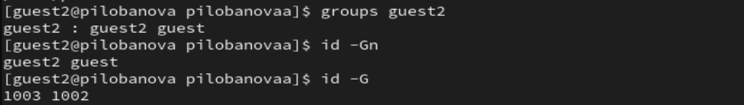

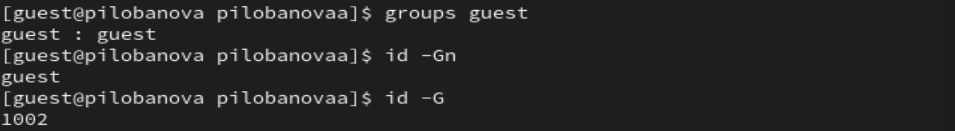

## .

7. Сравним полученную информацию с содержимым файла /etc/group.

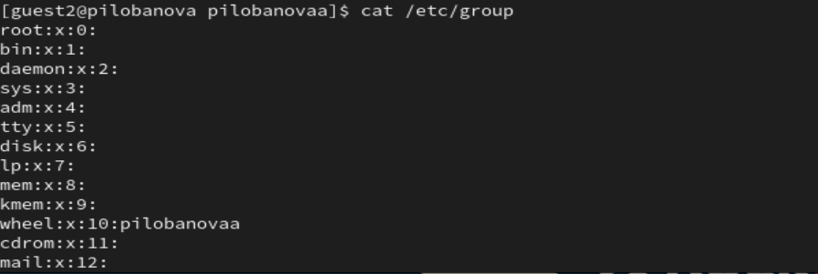

*Содержимое файла /etc/group.*

8. От имени пользователя guest2 выполним регистрацию пользователя guest2 в группе guest.

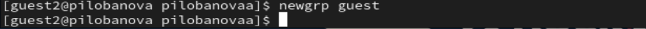

*Регистрация пользователя guest2 в группе guest.*

## .

9. От имени пользователя guest изменим права директории /home/guest, разрешив все действия для пользователей группы.

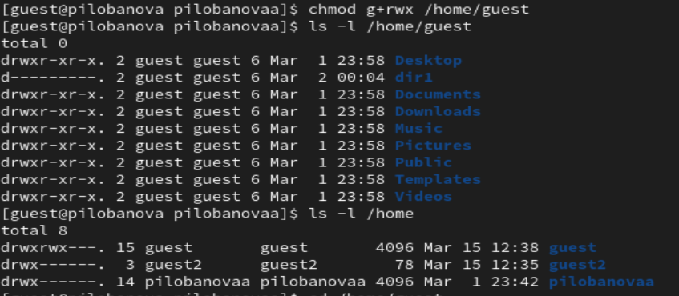

*Изменение прав директории /home/guest*

## .

10. От имени пользователя guest снимем с директории /home/guest/dir1 все атрибуты.

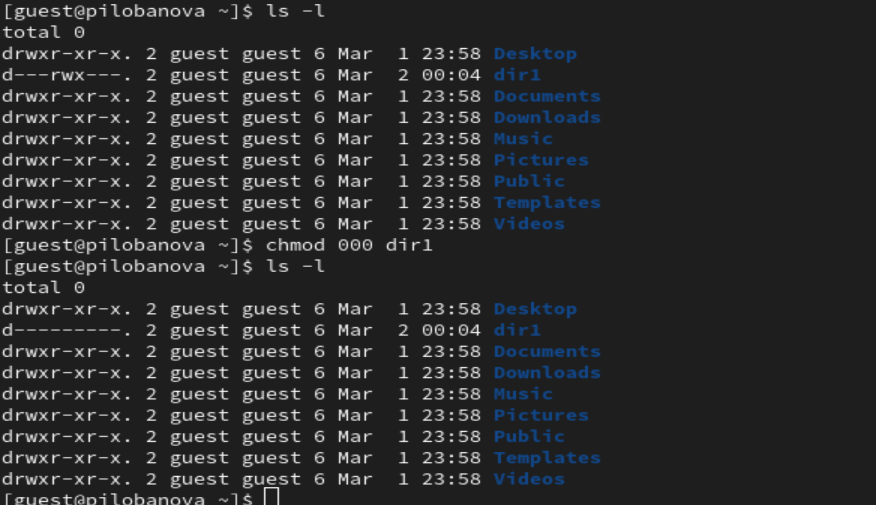

*Снятие всех атрибутов с директории /home/guest/dir1.*

## .

11. Меняя атрибуты у директории dir1 и файла file1 от имени пользователя guest и делая проверку от пользователя guest2, заполним табл. 3.1.

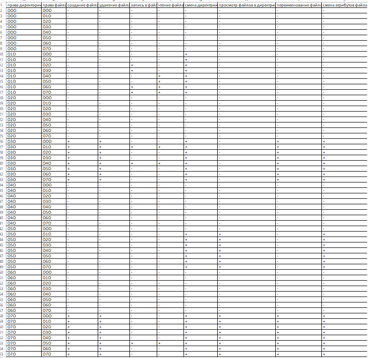

*Таблица 3.1.*

## .

12. На основании заполненной таблицы определим те или иные минимально необходимые права для выполнения пользователем guest2 операций внутри директории dir1 и заполните табл. 3.2.

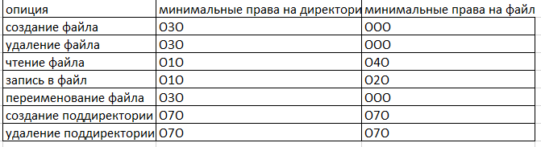

*Таблица 3.2.*

# Вывод

Я получила практические навыки работы в консоли с атрибутами файлов для групп пользователей.